# Trabajo Final Módulo Ciencia de Datos

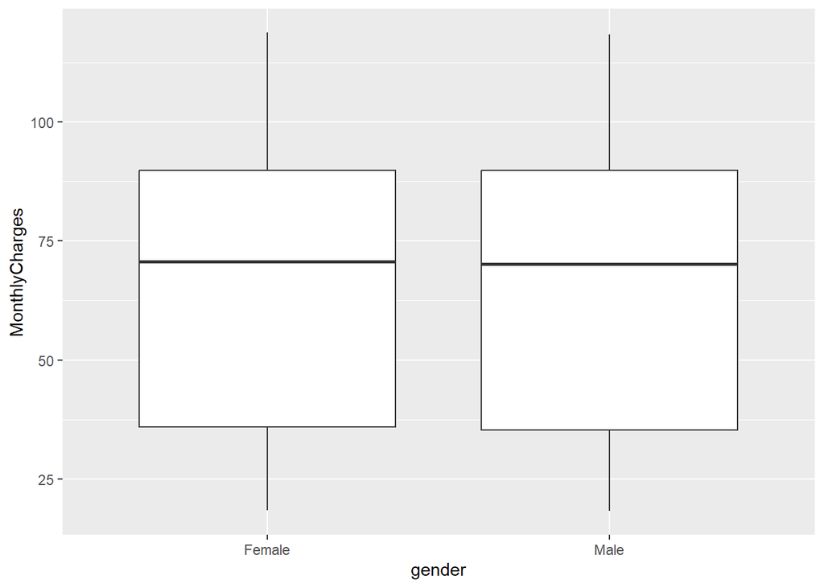

```r
gasto_mens %>% ggplot() +
  geom_boxplot(aes(gender, MonthlyCharges))
```

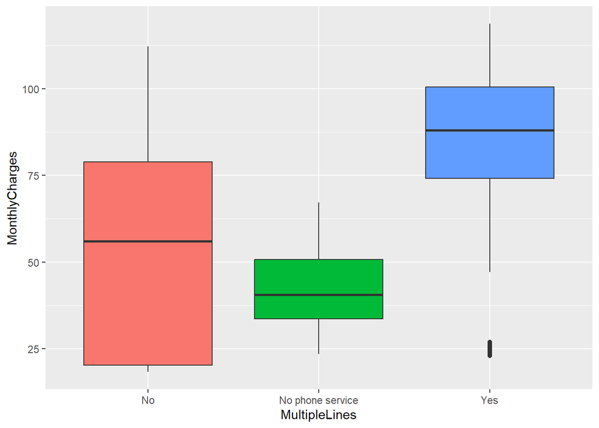

```r
gasto_mens %>% ggplot() +
  geom_boxplot(aes(MultipleLines, MonthlyCharges, fill=MultipleLines)) + theme(legend.position = 'none')
```

**Gasto mensual de las variables numéricas, correlación entre ellas**

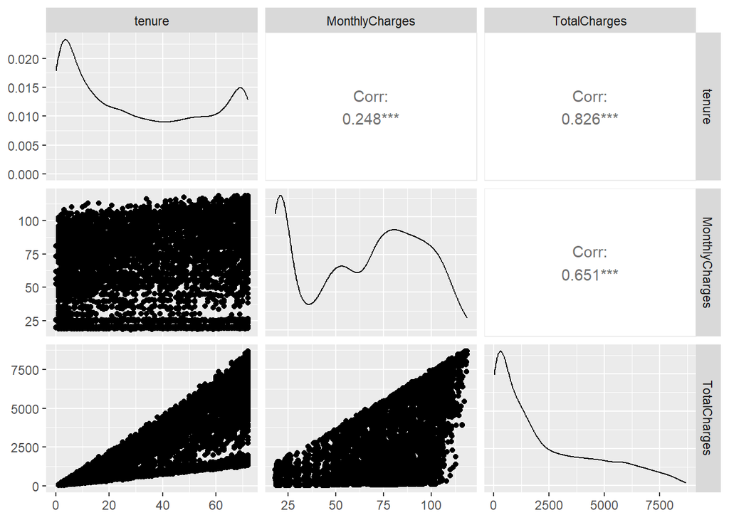

```r
churn_data %>%
  ggpairs(columns = c(6,19,20))
```

**Transformación de variables necesarias**

```r
churn_data$SeniorCitizen <- factor(churn_data$SeniorCitizen)
churn_data$SeniorCitizen <- ifelse(churn_data$SeniorCitizen== 1, "Yes", "No")
str(churn_data$SeniorCitizen)
```

```
##  chr [1:7043] "No" "No" "No" "No" "No" "No" "No" "No" "No" "No" "No" "No" "No" "No" "No" "No" ...
```

```r
class(churn_data$SeniorCitizen)
```

```
## [1] "character"
```

```r
churn_data[, -c(1,6,19,20)]<-lapply(churn_data[, -c(1,6,19,20)], as.factor)
str(churn_data)
```

```
## 'data.frame':    7043 obs. of  21 variables:
##  $ customerID      : chr  "7590-VHVEG" "5575-GNVDE" "3668-QPYBK" "7795-CFOCW" ...
##  $ gender          : Factor w/ 2 levels "Female","Male": 1 2 2 2 1 1 2 1 1 2 ...
##  $ SeniorCitizen   : Factor w/ 2 levels "No","Yes": 1 1 1 1 1 1 1 1 1 1 ...
##  $ Partner         : Factor w/ 2 levels "No","Yes": 2 1 1 1 1 1 1 1 2 1 ...
##  $ Dependents      : Factor w/ 2 levels "No","Yes": 1 1 1 1 1 1 2 1 1 2 ...
##  $ tenure          : int  1 34 2 45 2 8 22 10 28 62 ...
##  $ PhoneService    : Factor w/ 2 levels "No","Yes": 1 2 2 1 2 2 2 1 2 2 ...
##  $ MultipleLines   : Factor w/ 3 levels "No","No phone service",..: 2 1 1 2 1 3 3 2 3 1 ...
##  $ InternetService : Factor w/ 3 levels "DSL","Fiber optic",..: 1 1 1 1 2 2 2 1 2 1 ...
##  $ OnlineSecurity  : Factor w/ 3 levels "No","No internet service",..: 1 3 3 3 1 1 1 3 1 3 ...
##  $ OnlineBackup    : Factor w/ 3 levels "No","No internet service",..: 3 1 3 1 1 1 3 1 1 3 ...
##  $ DeviceProtection: Factor w/ 3 levels "No","No internet service",..: 1 3 1 3 1 3 1 1 3 1 ...
##  $ TechSupport     : Factor w/ 3 levels "No","No internet service",..: 1 1 1 3 1 1 1 1 3 1 ...
##  $ StreamingTV     : Factor w/ 3 levels "No","No internet service",..: 1 1 1 1 1 3 3 1 3 1 ...
##  $ StreamingMovies : Factor w/ 3 levels "No","No internet service",..: 1 1 1 1 1 3 1 1 3 1 ...
##  $ Contract        : Factor w/ 3 levels "Month-to-month",..: 1 2 1 2 1 1 1 1 1 2 ...
##  $ PaperlessBilling: Factor w/ 2 levels "No","Yes": 2 1 2 1 2 2 2 1 2 1 ...
##  $ PaymentMethod   : Factor w/ 4 levels "Bank transfer (automatic)",..: 3 4 4 1 3 3 2 4 3 1 ...
##  $ MonthlyCharges  : num  29.9 57 53.9 42.3 70.7 ...
##  $ TotalCharges    : num  29.9 1889.5 108.2 1840.8 151.7 ...
##  $ Churn           : Factor w/ 2 levels "No","Yes": 1 1 2 1 2 2 1 1 2 1 ...
```

**Sugerencias**

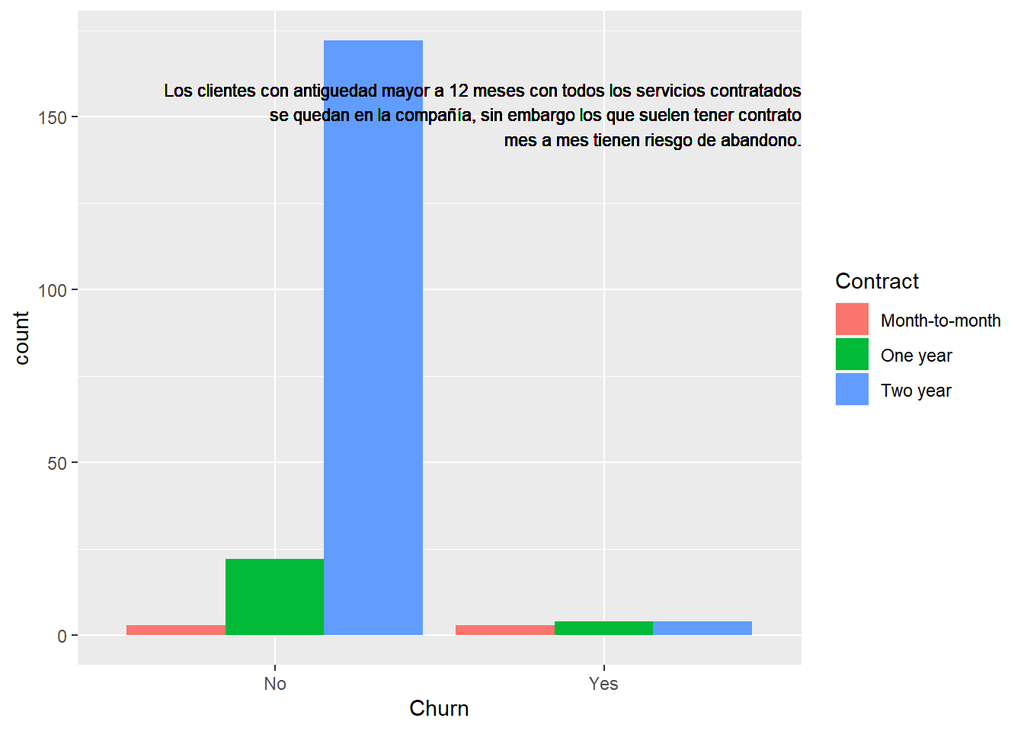

```r
long_contracts<-churn_data %>% filter( tenure>=12,InternetService !="No", PhoneService !="No", MultipleLines!="No", OnlineSecurity!="No", OnlineBackup!="No", DeviceProtection!="No", TechSupport!="No", StreamingTV!="No", StreamingMovies!="No") %>%
  select(tenure, PhoneService, MultipleLines,InternetService,OnlineSecurity,OnlineBackup,DeviceProtection,TechSupport,StreamingTV,StreamingMovies,Churn, InternetService, Contract)


long_contracts %>%
ggplot() + geom_bar(aes(Churn, fill=Contract), position = "dodge") +
  geom_text(data=NULL,x=2.6, y= 160, label="Los clientes con antiguedad mayor a 12 meses con todos los servicios contratados\n  se quedan en la compañía, sin embargo los que suelen tener contrato\n  mes a mes tienen riesgo de abandono.", vjust="top", hjust="right", size=3, color="black")
```

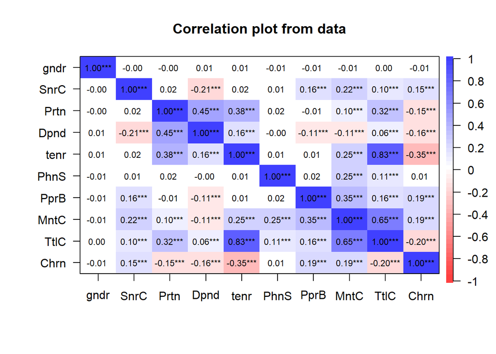

```r
churn_data_numeric <- data.frame(lapply(churn_data[, -c(1)], as.numeric))
psych::corPlot(churn_data_numeric[,c(1,2,3,4,5,6,16,18,19,20)], min.length = 4, cex = 0.75, stars = TRUE)
```

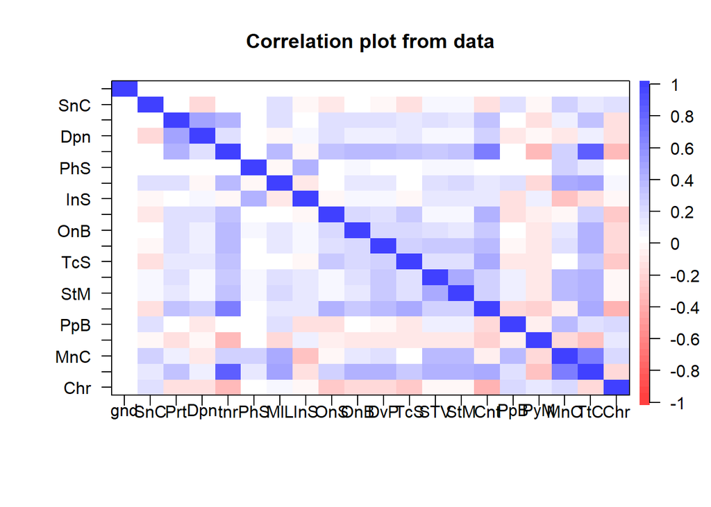

```r
psych::corPlot(churn_data_numeric, min.length = 3, numbers = FALSE)
```

[output not shown]

[output not shown]

[output not shown]

[output not shown]

[output not shown]

[figure not shown]

```r
# Código para creación de conjuntos de entrenamiento y test
churn_train <- churn_data[1:5000,]
churn_test <- churn_data[-(1:5000),]

churn_mod<- churn_train[-c(1,20,21)]
```

# Modelos de Regresión Lineal

```r
modelo <- lm(MonthlyCharges~., data = churn_mod)
summary(modelo)
```

```
##
## Call:
## lm(formula = MonthlyCharges ~ ., data = churn_mod)
##
## Residuals:
##     Min      1Q  Median      3Q     Max
## -4.1945 -0.5985  0.0031  0.6012  4.8558
##
## Coefficients: (7 not defined because of singularities)
##                                        Estimate Std. Error  t value Pr(>|t|)
## (Intercept)                           2.494e+01  6.914e-02  360.768   <2e-16 ***
## genderMale                            6.776e-03  2.887e-02    0.235    0.814
## SeniorCitizenYes                      2.394e-03  4.203e-02    0.057    0.955
## PartnerYes                           -1.442e-02  3.519e-02   -0.410    0.682
## DependentsYes                         3.866e-02  3.713e-02    1.041    0.298
## tenure                                1.047e-04  9.937e-04    0.105    0.916
## PhoneServiceYes                       2.006e+01  5.752e-02  348.774   <2e-16 ***
## MultipleLinesNo phone service                NA         NA       NA       NA
## MultipleLinesYes                      5.006e+00  3.460e-02  144.683   <2e-16 ***
## InternetServiceFiber optic            2.498e+01  4.091e-02  610.653   <2e-16 ***
## InternetServiceNo                    -2.505e+01  5.699e-02 -439.572   <2e-16 ***
## OnlineSecurityNo internet service            NA         NA       NA       NA
## OnlineSecurityYes                     4.999e+00  3.815e-02  131.035   <2e-16 ***
## OnlineBackupNo internet service              NA         NA       NA       NA
## OnlineBackupYes                       5.010e+00  3.578e-02  140.002   <2e-16 ***
## DeviceProtectionNo internet service          NA         NA       NA       NA
## DeviceProtectionYes                   5.027e+00  3.703e-02  135.756   <2e-16 ***
## TechSupportNo internet service               NA         NA       NA       NA
## TechSupportYes                        5.024e+00  3.905e-02  128.639   <2e-16 ***
## StreamingTVNo internet service               NA         NA       NA       NA
## StreamingTVYes                        9.946e+00  3.807e-02  261.246   <2e-16 ***
## StreamingMoviesNo internet service           NA         NA       NA       NA
## StreamingMoviesYes                    9.984e+00  3.799e-02  262.834   <2e-16 ***
## ContractOne year                      1.503e-02  4.541e-02    0.331    0.741
## ContractTwo year                      1.713e-02  5.505e-02    0.311    0.756
## PaperlessBillingYes                  -1.929e-04  3.236e-02   -0.006    0.995
## PaymentMethodCredit card (automatic) -6.483e-02  4.356e-02   -1.488    0.137
## PaymentMethodElectronic check        -2.002e-02  4.287e-02   -0.467    0.641
## PaymentMethodMailed check            -1.595e-02  4.677e-02   -0.341    0.733
## ---
## Signif. codes:  0 '***' 0.001 '**' 0.01 '*' 0.05 '.' 0.1 ' ' 1
##
## Residual standard error: 1.019 on 4978 degrees of freedom
## Multiple R-squared:  0.9989, Adjusted R-squared:  0.9989
## F-statistic: 2.08e+05 on 21 and 4978 DF,  p-value: < 2.2e-16
```

```r
predict.test<- predict(modelo, newdata = churn_test)
rmse.test<- sqrt(mean((predict.test-churn_test$MonthlyCharges)^2))
```

Error cuadrático medio RMSE 1.0456342

# Modelos de clasificación

```r
churn_train<- churn_train[,-c(1)]
mod_log<- glm(Churn ~., data = churn_train, family = binomial)
summary(mod_log)
```

```
##
## Call:
## glm(formula = Churn ~ ., family = binomial, data = churn_train)
##
## Coefficients: (7 not defined because of singularities)
##                                        Estimate Std. Error z value Pr(>|z|)
## (Intercept)                           2.041e+00  9.781e-01   2.087 0.036913 *
## genderMale                           -3.655e-02  7.762e-02  -0.471 0.637726
## SeniorCitizenYes                      1.603e-01  1.007e-01   1.591 0.111602
## PartnerYes                            1.889e-02  9.412e-02   0.201 0.840923
## DependentsYes                        -1.370e-01  1.081e-01  -1.268 0.204835
## tenure                               -5.838e-02  7.614e-03  -7.668 1.75e-14 ***
## PhoneServiceYes                       9.071e-01  7.830e-01   1.159 0.246653
## MultipleLinesNo phone service                NA         NA      NA       NA
## MultipleLinesYes                      6.454e-01  2.122e-01   3.041 0.002360 **
## InternetServiceFiber optic            2.695e+00  9.627e-01   2.799 0.005126 **
## InternetServiceNo                    -2.769e+00  9.714e-01  -2.851 0.004364 **
## OnlineSecurityNo internet service            NA         NA      NA       NA
## OnlineSecurityYes                    -2.475e-02  2.140e-01  -0.116 0.907939
## OnlineBackupNo internet service              NA         NA      NA       NA
## OnlineBackupYes                       2.161e-01  2.110e-01   1.024 0.305834
## DeviceProtectionNo internet service          NA         NA      NA       NA
## DeviceProtectionYes                   3.105e-01  2.119e-01   1.465 0.142897
## TechSupportNo internet service               NA         NA      NA       NA
## TechSupportYes                       -1.209e-01  2.170e-01  -0.557 0.577262
## StreamingTVNo internet service               NA         NA      NA       NA
## StreamingTVYes                        9.948e-01  3.932e-01   2.530 0.011410 *
## StreamingMoviesNo internet service           NA         NA      NA       NA
## StreamingMoviesYes                    9.721e-01  3.940e-01   2.467 0.013615 *
## ContractOne year                     -6.307e-01  1.300e-01  -4.851 1.23e-06 ***
## ContractTwo year                     -1.474e+00  2.251e-01  -6.548 5.82e-11 ***
## PaperlessBillingYes                   3.296e-01  8.933e-02   3.689 0.000225 ***
## PaymentMethodCredit card (automatic) -1.272e-01  1.374e-01  -0.926 0.354462
## PaymentMethodElectronic check         3.515e-01  1.126e-01   3.123 0.001793 **
## PaymentMethodMailed check            -3.556e-02  1.379e-01  -0.258 0.796477
## MonthlyCharges                       -7.708e-02  3.826e-02  -2.015 0.043943 *
## TotalCharges                          3.047e-04  8.573e-05   3.554 0.000380 ***
## ---
## Signif. codes:  0 '***' 0.001 '**' 0.01 '*' 0.05 '.' 0.1 ' ' 1
##
## (Dispersion parameter for binomial family taken to be 1)
##
##     Null deviance: 5752.7  on 4991  degrees of freedom
## Residual deviance: 4069.0  on 4968  degrees of freedom
##   (8 observations deleted due to missingness)
## AIC: 4117
##
## Number of Fisher Scoring iterations: 6
```

```r
prob<- predict(mod_log, type = "response", newdata=churn_test)
churn_pred<- ifelse( prob>0.5,"Yes", "No")
matriz_conf<-table(churn_test$Churn, churn_pred)
kable(matriz_conf)
```

|  | No | Yes |
| --- | --- | --- |
| No | 1337 | 147 |
| Yes | 258 | 298 |

```r
er.clas<-(matriz_conf[1,2]+matriz_conf[2,1])/nrow(churn_test)


Accuracy<- (matriz_conf[1,1]+matriz_conf[2,2])/(matriz_conf[1,1] + matriz_conf[1,2] +   matriz_conf[2,2] + matriz_conf[2,1])
FPR<- (matriz_conf[1,2])/(matriz_conf[1,2]+ matriz_conf[1,1])
FNR<- (matriz_conf[2,1])/(matriz_conf[2,1] + matriz_conf[2,2])
TPR<- (matriz_conf[2,2])/ (matriz_conf[2,1]+ matriz_conf[2,2])
```

Precisión global de la predicción 0.801

Ratio falsos positivos 0.099

Ratio falsos negativos 0.464

Ratio verdaderos positivos 0.536

**Otro modelo de clasificación**

```r
mod2 <- glm(Churn~Contract + tenure + InternetService, data=churn_train, family = binomial)
(summary(mod2))
```

```
##
## Call:
## glm(formula = Churn ~ Contract + tenure + InternetService, family = binomial,
##     data = churn_train)
##
## Coefficients:
##                             Estimate Std. Error z value Pr(>|z|)
## (Intercept)                -0.342809   0.074589  -4.596 4.31e-06 ***
## ContractOne year           -0.840880   0.123487  -6.809 9.80e-12 ***
## ContractTwo year           -1.871985   0.215830  -8.673  < 2e-16 ***
## tenure                     -0.031043   0.002325 -13.352  < 2e-16 ***
## InternetServiceFiber optic  1.214033   0.086650  14.011  < 2e-16 ***
## InternetServiceNo          -1.082981   0.141722  -7.642 2.15e-14 ***
## ---
## Signif. codes:  0 '***' 0.001 '**' 0.01 '*' 0.05 '.' 0.1 ' ' 1
##
## (Dispersion parameter for binomial family taken to be 1)
##
##     Null deviance: 5757.6  on 4999  degrees of freedom
## Residual deviance: 4255.2  on 4994  degrees of freedom
## AIC: 4267.2
##
## Number of Fisher Scoring iterations: 6
```

```r
prob1<- predict(mod2, type = "response", newdata=churn_test);predict
```

```
## function (object, ...)
## UseMethod("predict")
## <bytecode: 0x000001f2fb686278>
## <environment: namespace:stats>
```

```r
churn_pred2<- ifelse( prob1>0.5,"Yes", "No")
t<- table(churn_test$Churn, churn_pred2)
kable(t)
```

|  | No | Yes |
| --- | --- | --- |
| No | 1342 | 145 |
| Yes | 293 | 263 |

```r
er.2<- (t[1,2]+t[2,1])/nrow(churn_test)
Accuracy2<- (t[1,1]+t[2,2])/(t[1,1] + t[1,2] +   t[2,2] + t[2,1])
FPR2<- (t[1,2])/(t[1,2]+ t[1,1])
FNR2<- (t[2,1])/(t[2,1] + t[2,2])
TPR2<- (t[2,2])/ (t[2,1]+ t[2,2])
```

Error de clasificación 0.214

Precisión global de la predicción 0.786

Ratio falsos positivos 0.098

Ratio falsos negativos 0.527

Ratio verdaderos positivos 0.473

# Simulación de campaña de Retención

```r
probs<-predict(mod_log, type="response", newdata=churn_test)
up<- seq(0,1,0.1)
pred_churn<- ifelse(probs>up,"Yes","No")
tb <- table(churn_test$Churn, pred_churn)
kable(tb)
```

|  | No | Yes |
| --- | --- | --- |
| No | 1166 | 318 |
| Yes | 298 | 258 |

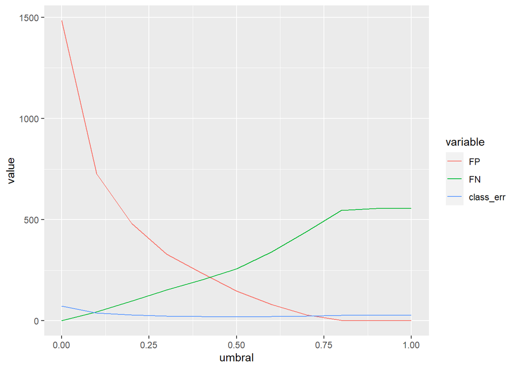

```r
fp <- c(rep(NA, 11))
fn <- c(rep(NA, 11))
tp <- c(rep(NA, 11))
ce <- c(rep(NA, 11))
cp <- c(rep(NA, 11))
for (i in 1:length(up)) {
  rm(clase, table)
  clase=factor(ifelse(probs>up[i], "Yes", "No"), levels =
                  c("No", "Yes"))
  table <- table(churn_test$Churn, clase)
  fp[i] <- table[1,2]
  fn[i] <- table[2,1]
  tp[i] <- table[2,2]
  ce[i] <- (table[1,2] + table[2,1]) / sum(table)*100
  cp[i] <- sum(table[,2])/sum(table)*100

}

res <- cbind(data.frame(umbral = up, FP = fp, FN = fn, TP = tp, class_err = ce, classpos = cp))

ggplot(melt(res, id="umbral", measure=c("FP", "FN","class_err"))) +
  geom_line(aes(umbral, value, color=variable)) + xlim(0,1)
```

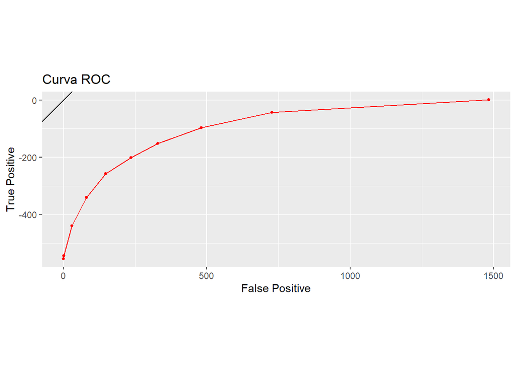

```r
ggplot(res) +
  geom_line(aes(FP,1- FN ), color="red") +
  geom_point(aes(FP,1- FN ), color="red", size=1) +
  geom_abline(aes(intercept=0, slope= 1)) + coord_equal() +
  ylab("True Positive") + xlab("False Positive") +
  labs(title = "Curva ROC")
```

**Campaña incentivo 1**

```r
prob_umbral<- res[,1]
I_ <- 200
AR_ <- 0.4
R_ <- 500
simula_1 <- data.frame()

for (i in 1:length(prob_umbral)) {

  FN <- res[(i),"FN"]
  FP <- res[(i), "FP"]
  TP <- res[(i), "TP"]

  resconcamp_<- -FP*AR_*I_ - TP*AR_*I_ - TP*(1-AR_)*R_ - FN* R_
  ressincamp_<- -(FN + TP)*R_

  simula_1<- rbind(simula_1, data.frame(umbral=prob_umbral[i], ConCampaña=resconcamp_, SinCampaña=ressincamp_, beneficio= resconcamp_-ressincamp_))
}

umbral_optimo <- simula_1[which.max(simula_1$beneficio),1]
beneficio <- simula_1$beneficio[simula_1$umbral==umbral_optimo]
```

El umbral de clientes óptimo será 0.5

Generará un beneficio de 2.4^{4} Euros

**Campaña incentivo 2**

```r
I <- 400
AR<- 0.8
R<- 500

 simula_2<- data.frame()

for (i in 1:length(prob_umbral)) {
  FN <- res[(i),"FN"]
  FP <- res[(i), "FP"]
  TP <- res[(i), "TP"]

  resconcamp<- -FP*AR*I - TP*AR*I - TP*(1-AR)*R - FN* R
  ressincamp<- -(FN + TP)*R

  simula_2<- rbind(simula_2, data.frame(umbral=prob_umbral[i], resConCamp=resconcamp, resSinCamp=ressincamp, beneficio= resconcamp-ressincamp) )
}

umbral_optimo1 <- simula_2[which.max(simula_2$beneficio),1]; umbral_optimo1
```

```
## [1] 0.8
```

```r
beneficio1 <- simula_2$beneficio[simula_2$umbral==umbral_optimo1]

dif_bnf<- beneficio - beneficio1
```

El umbral de clientes óptimo será 0.8.

Generará un beneficio de 240 Euros.

Se optiene peor resultados respecto a la campaña con incentivo menor, con una diferencia de 2.376^{4} Euros menos respecto a la campaña anterior.